# User Car Price Analysis

Utkal Sirikonda

## 1 Abstract

In this study, we take used cars catalog of cars in the market over the years. From the available quantitative variables, we try to arrive at a multiple regression model to estimate the price of the car based on the quantitative values. We also analyse which variables are actually contributing to the price of the used car.

### 1.1 Note

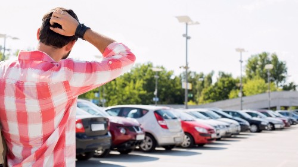

Purchasing a Used Car

## 2 Introduction

In this project, we study used car data. Analyzing used cars for their reliability is a huge deal for people who are willing to buy one.

## 3 Data

### 3.1 Collection

- The data-set is obtained from Kaggle: [used-car-catalog](https://www.kaggle.com/datasets/lepchenkov/usedcarscatalog?resource=download)
- As mentioned in the source, the data is collected from various web resources in order to explore the used cars market.
- This data-set contains used car ads from a popular online catalogs in Belarus on December 2nd, 2019.
- The data-set contains 30 variables, where each row is a car ad, described by manufacturer, model, mileage, production year, and many other properties.

### 3.2 Importing Data

The top rows of raw data looks like:

|  | manufacturer_name | model_name | transmission | color | odometer_value | year_produced | engine_fuel | engine_has_gas | engine_type | engine_capacity | body_type | has_warranty | state | drivetrain | price_usd | is_exchangeable | location_region | number_of_photos | up_counter | feature_0 | feature_1 | feature_2 | feature_3 | feature_4 | feature_5 | feature_6 | feature_7 | feature_8 | feature_9 | … |
| --- | --- | --- | --- | --- | --- | --- | --- | --- | --- | --- | --- | --- | --- | --- | --- | --- | --- | --- | --- | --- | --- | --- | --- | --- | --- | --- | --- | --- | --- | --- |
| 1 | Subaru | Outback | automatic | silver | 190000 | 2010 | gasoline | False | gasoline | 2.5 | universal | False | owned | all | 10900 | False | Минская обл. | 9 | 13 | False | True | True | True | False | True | False | True | True | True | … |
| 2 | Subaru | Outback | automatic | blue | 290000 | 2002 | gasoline | False | gasoline | 3 | universal | False | owned | all | 5000 | True | Минская обл. | 12 | 54 | False | True | False | False | True | True | False | False | False | True | … |
| 3 | Subaru | Forester | automatic | red | 402000 | 2001 | gasoline | False | gasoline | 2.5 | suv | False | owned | all | 2800 | True | Минская обл. | 4 | 72 | False | True | False | False | False | False | False | False | True | True | … |
| 4 | Subaru | Impreza | mechanical | blue | 10000 | 1999 | gasoline | False | gasoline | 3 | sedan | False | owned | all | 9999 | True | Минская обл. | 9 | 42 | True | False | False | False | False | False | False | False | False | False | … |
| 5 | Subaru | Legacy | automatic | black | 280000 | 2001 | gasoline | False | gasoline | 2.5 | universal | False | owned | all | 2134.11 | True | Гомельская обл. | 14 | 7 | False | True | False | True | True | False | False | False | False | True | … |
| 6 | Subaru | Outback | automatic | silver | 132449 | 2011 | gasoline | False | gasoline | 2.5 | universal | False | owned | all | 14700 | True | Минская обл. | 20 | 56 | False | True | False | False | False | True | False | True | True | True | … |

Some key observations

- Any record without manufacturer_name, model_name, year_produced doesn’t describe the car properly, so any such records are eliminated.
- Boolean variables (engine_has_gas, has_warranty, is_exchangeable, feature_*) contain character strings “False”/“True” instead of logical values TRUE/FALSE.
- Feature variables (feature_0 to feature_9) don’t contribute semantically to our analysis as they are not described properly. So, we can either choose to neglect them, or we can just count the number of features and make a new variable out of it.
- Select variables of interest and neglect the rest.
- Naming variables can be improvised

### 3.3 Data Manipulation

1. Filter records with manufacturer_name, model_name, year_produced as NA.
2. Convert Boolean Columns to Logical Type (TRUE/FALSE).
3. Reshape feature_0 to feature_9 into a feature_count.
4. Filter out un-required variables.

|  | manufacturer_name | model_name | year_produced | engine_type | engine_capacity | transmission | body_type | drivetrain | color | mileage | engine_fuel | state | location_region | number_of_photos | price_usd | has_warranty | is_exchangeable | duration_listed | up_counter | feature_count |
| --- | --- | --- | --- | --- | --- | --- | --- | --- | --- | --- | --- | --- | --- | --- | --- | --- | --- | --- | --- | --- |
| 1 | Subaru | Outback | 2010 | gasoline | 2.5 | automatic | universal | all | silver | 190000 | gasoline | owned | Минская обл. | 9 | 10900 | False | False | 16 | 13 | 7 |
| 2 | Subaru | Outback | 2002 | gasoline | 3 | automatic | universal | all | blue | 290000 | gasoline | owned | Минская обл. | 12 | 5000 | False | True | 83 | 54 | 4 |
| 3 | Subaru | Forester | 2001 | gasoline | 2.5 | automatic | suv | all | red | 402000 | gasoline | owned | Минская обл. | 4 | 2800 | False | True | 151 | 72 | 3 |
| 4 | Subaru | Impreza | 1999 | gasoline | 3 | mechanical | sedan | all | blue | 10000 | gasoline | owned | Минская обл. | 9 | 9999 | False | True | 86 | 42 | 1 |
| 5 | Subaru | Legacy | 2001 | gasoline | 2.5 | automatic | universal | all | black | 280000 | gasoline | owned | Гомельская обл. | 14 | 2134.11 | False | True | 7 | 7 | 4 |
| 6 | Subaru | Outback | 2011 | gasoline | 2.5 | automatic | universal | all | silver | 132449 | gasoline | owned | Минская обл. | 20 | 14700 | False | True | 67 | 56 | 5 |
| 7 | Subaru | Forester | 1998 | gasoline | 2.5 | automatic | universal | all | black | 318280 | gasoline | owned | Минская обл. | 8 | 3000 | False | True | 307 | 147 | 5 |
| 8 | Subaru | Legacy | 2004 | gasoline | 2.5 | automatic | sedan | all | silver | 350000 | gasoline | owned | Брестская обл. | 7 | 4500 | False | False | 73 | 29 | 3 |
| 9 | Subaru | Outback | 2010 | gasoline | 2.5 | automatic | universal | all | grey | 179000 | gasoline | owned | Минская обл. | 17 | 12900 | False | False | 87 | 33 | 9 |
| 10 | Subaru | Forester | 1999 | gasoline | 2.5 | automatic | universal | all | silver | 571317 | gasoline | owned | Минская обл. | 8 | 4200 | False | True | 43 | 11 | 4 |

[output cut: 38521 more lines]

### 3.4 Final Data - Sampling

When using all the records from processed data, we see much variance, and the distribution doesn’t fit in Normal Distribution.

To show this, we try displaying a few graphs:

#### 3.4.1 QQ Plot over processed data

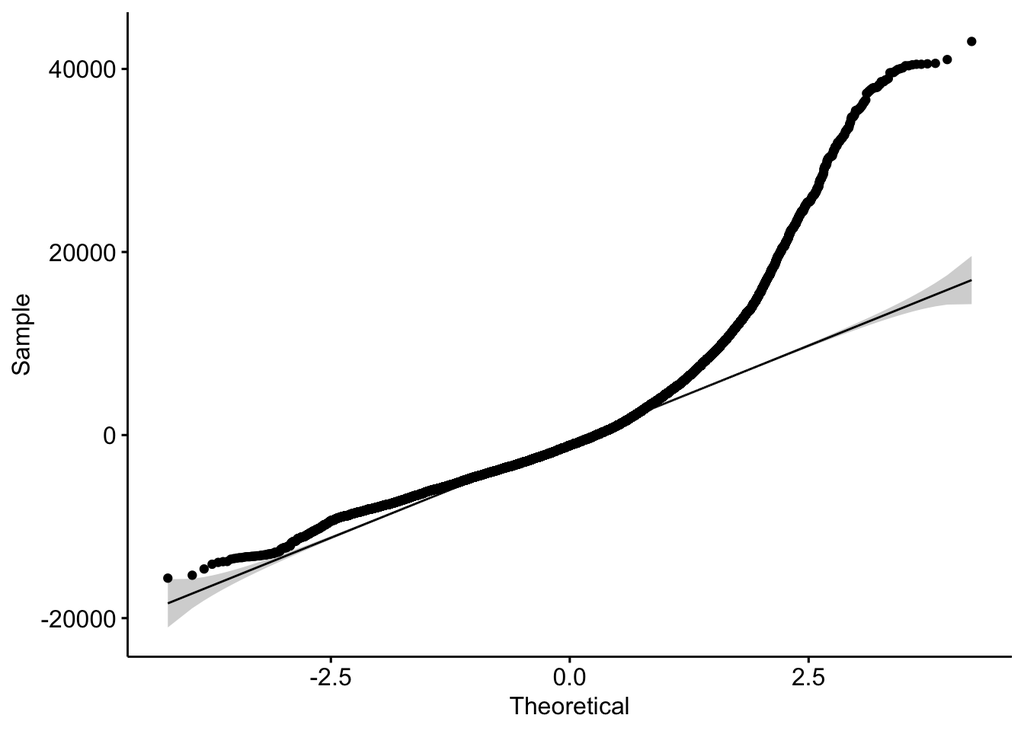

The plot deviates significantly and it doesn’t look like a normal distribution.

#### 3.4.2 Mileage vs Price

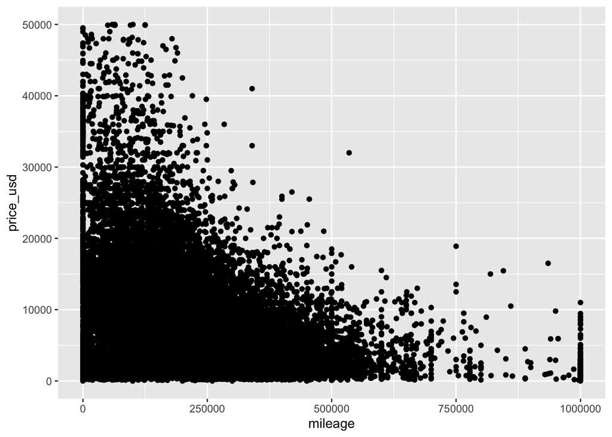

Complete processed data doesn’t display much of a pattern since it is dense until 500000 km mileage.

#### 3.4.3 Random samples

As we sample the data, we start to observe patterns and it seems to be more normally distributed.

Taking 50 random samples from processed data:

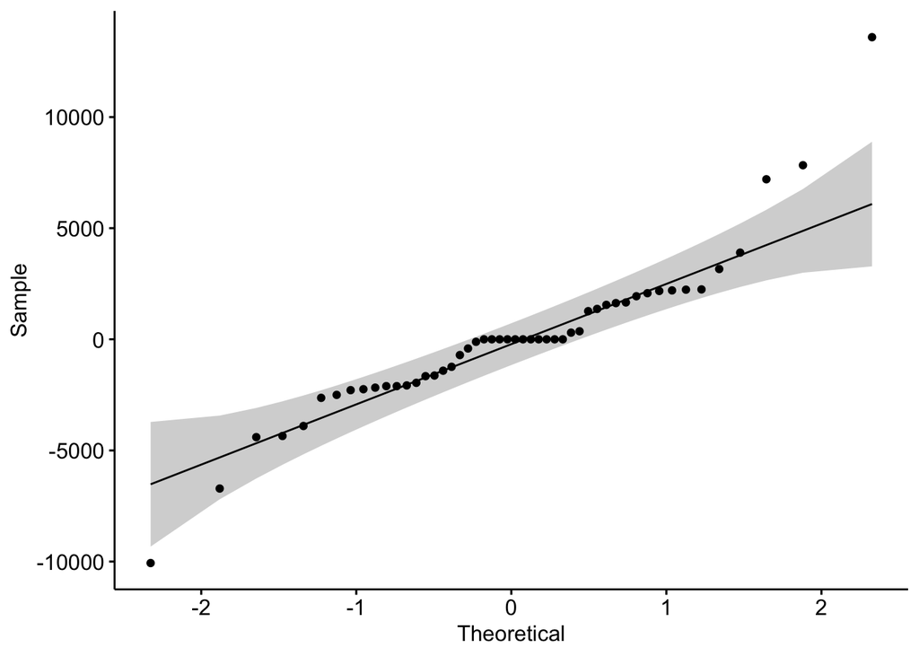

This looks more normal with minor deviations. So, the sampled data can be applicable for ANOVA test.

We can observe a pattern for sampled data. As mileage increases, price decreases:

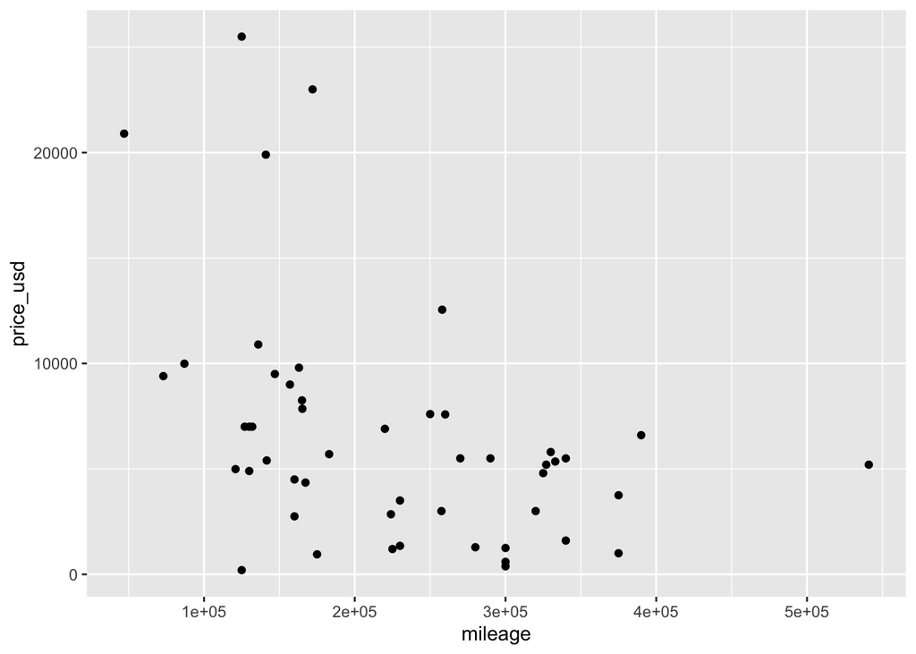

### 3.5 Description of Variables

|  | Variable | Type | Description |
| --- | --- | --- | --- |
| 1 | manufacturer_name | Categorical | Manufacturer of the car |
| 2 | model_name | Categorical | Model name of the car |
| 3 | year_produced | Numeric | Year the car was produced |
| 4 | engine_type | Categorical | Type of engine (e.g., gasoline, diesel) |
| 5 | engine_capacity | Numeric | Engine capacity in liters |
| 6 | transmission | Categorical | Type of transmission (automatic or mechanical) |
| 7 | body_type | Categorical | Body style (e.g., sedan, suv, universal) |
| 8 | drivetrain | Categorical | Drivetrain type (all, front, rear) |
| 9 | color | Categorical | Color of the car |
| 10 | mileage | Numeric | Mileage (in kilometers) |

[output cut: 10 more lines]

## 4 Descriptive Statistics

|  | variable_name | count | mean | sd |
| --- | --- | --- | --- | --- |
| 1 | duration_listed | 38531 | 80.57724948742592 | 112.826568642614 |
| 2 | engine_capacity | 38521 | 2.055161106928698 | 0.6711776672087653 |
| 3 | feature_count | 38531 | 3.36235758220666 | 2.582049694304457 |
| 4 | mileage | 38531 | 248864.6384469632 | 136072.3765297831 |
| 5 | number_of_photos | 38531 | 9.64906179439941 | 6.093216996872521 |
| 6 | price_usd | 38531 | 6639.971021255083 | 6428.152018202927 |
| 7 | up_counter | 38531 | 16.30609119929399 | 43.28693309422091 |
| 8 | year_produced | 38531 | 2002.943733617087 | 8.065730511310065 |

We observe that the Standard Deviation for mileage is significant inferring there are cars with varying mileage.

## 5 Multiple Regression to estimate Price

We display patterns of how each quantitative variable affects price of car.

As mileage increases, price decreases:

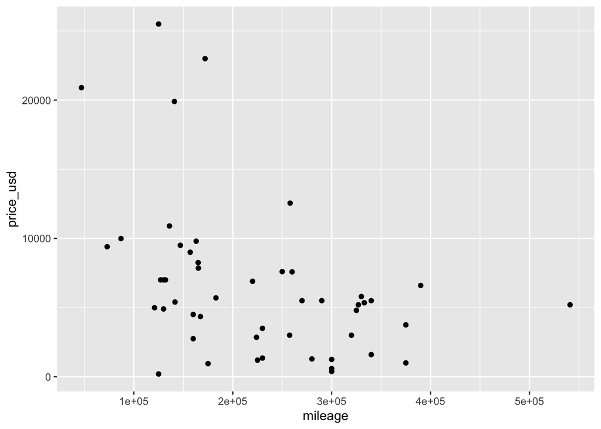

Similarly, year produced also seems to affect price of the car after looking at Sampled data.

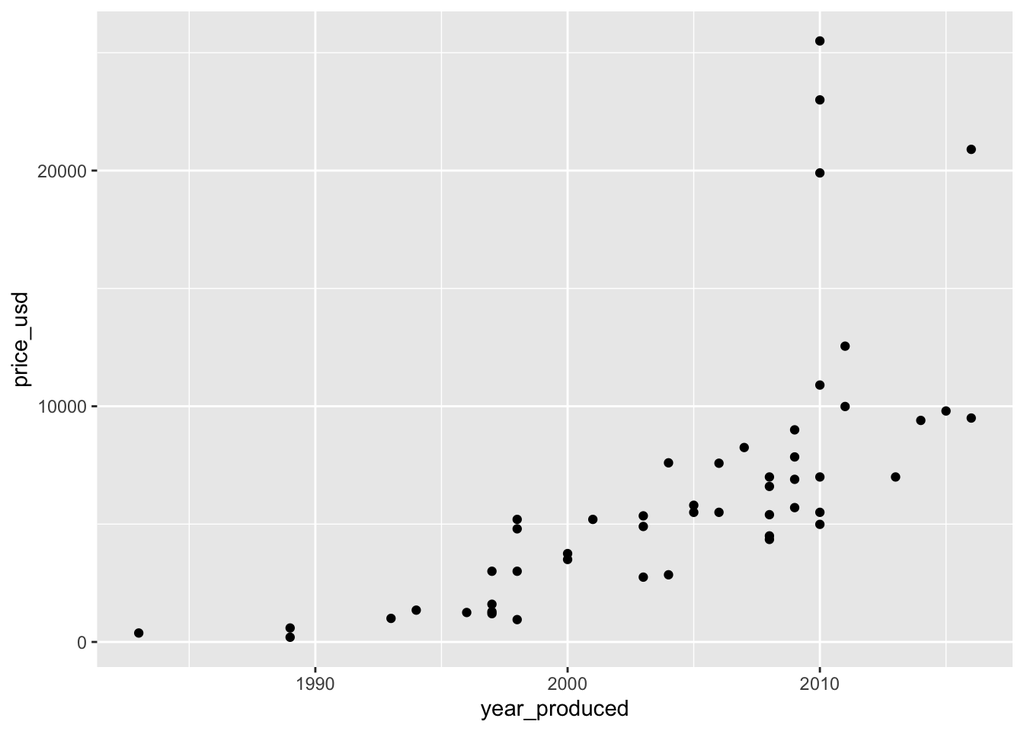

Plotting other variables against price to check if any of them affect price of the used car.

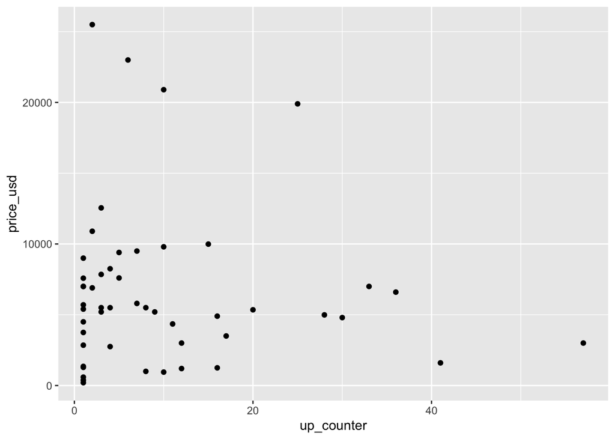

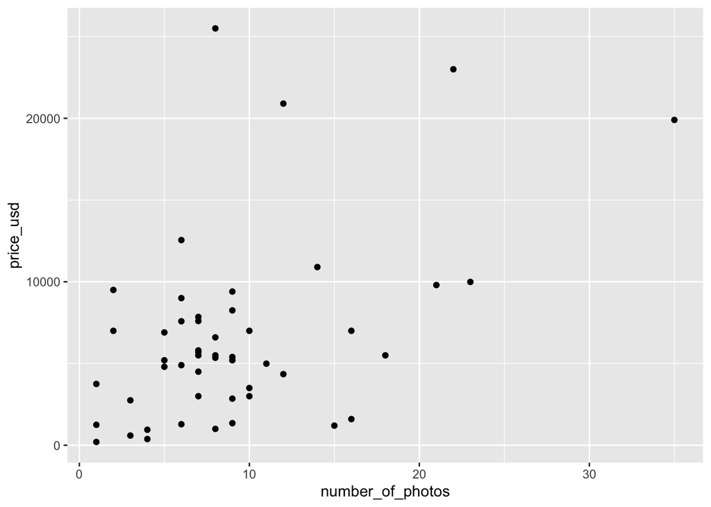

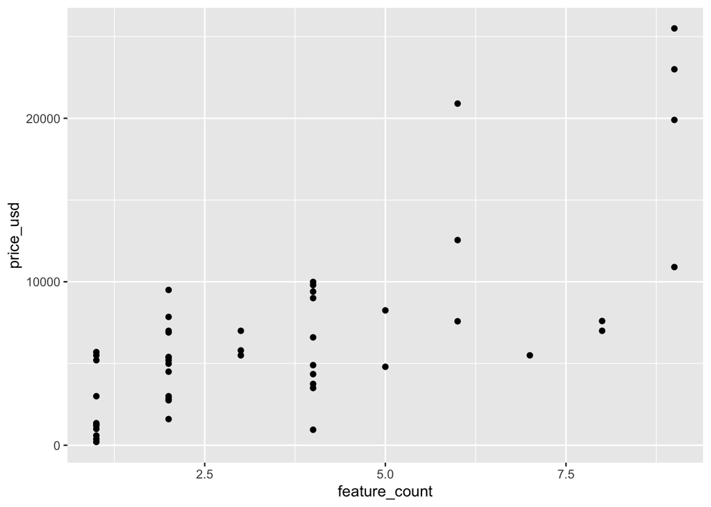

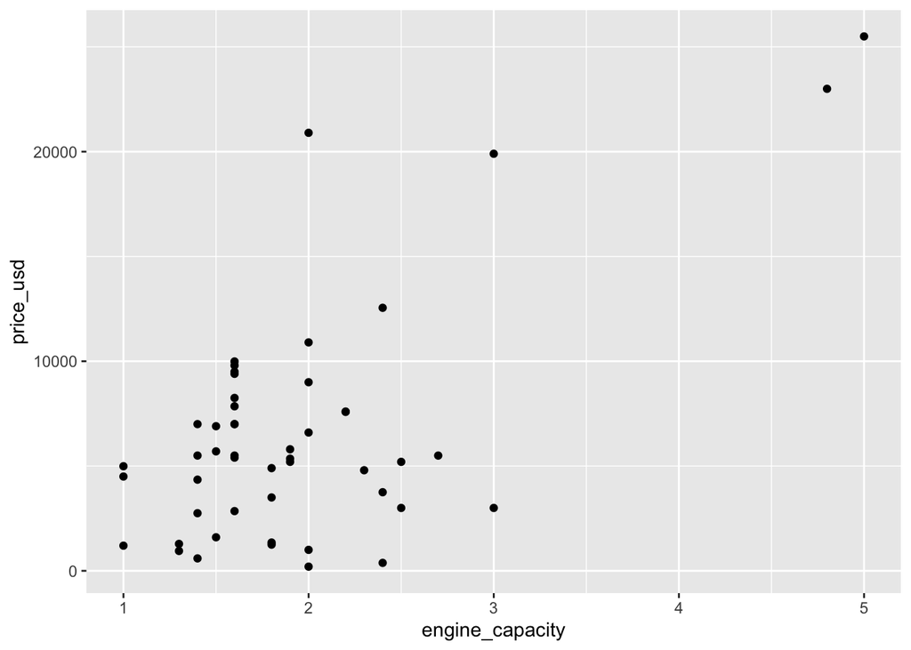

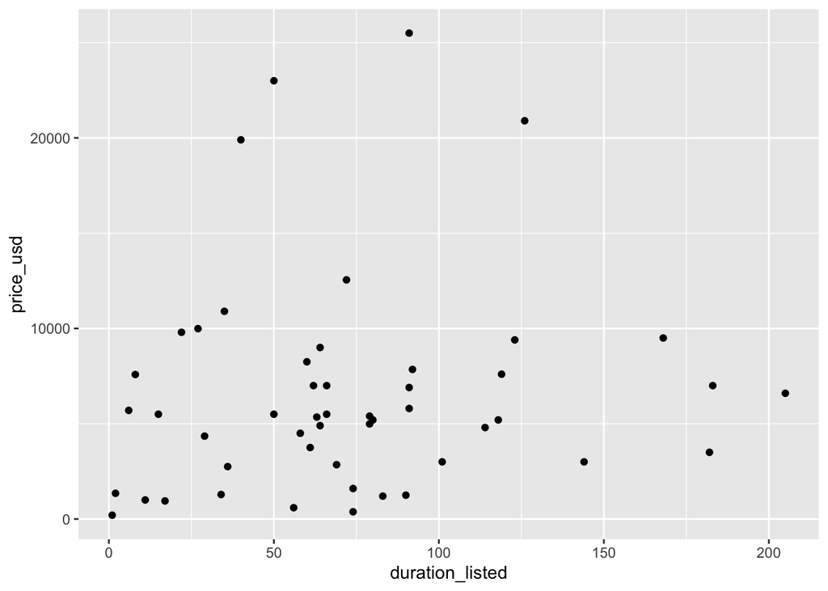

From the plots, it is observed that Mileage, Year of production, Number of Photos for the listing, Number of features, Engine Capacity of the car influence the price of the used car. So, we choose those variables as explanatory variables and apply the Multi- Linear Regression model to estimate price of the car.

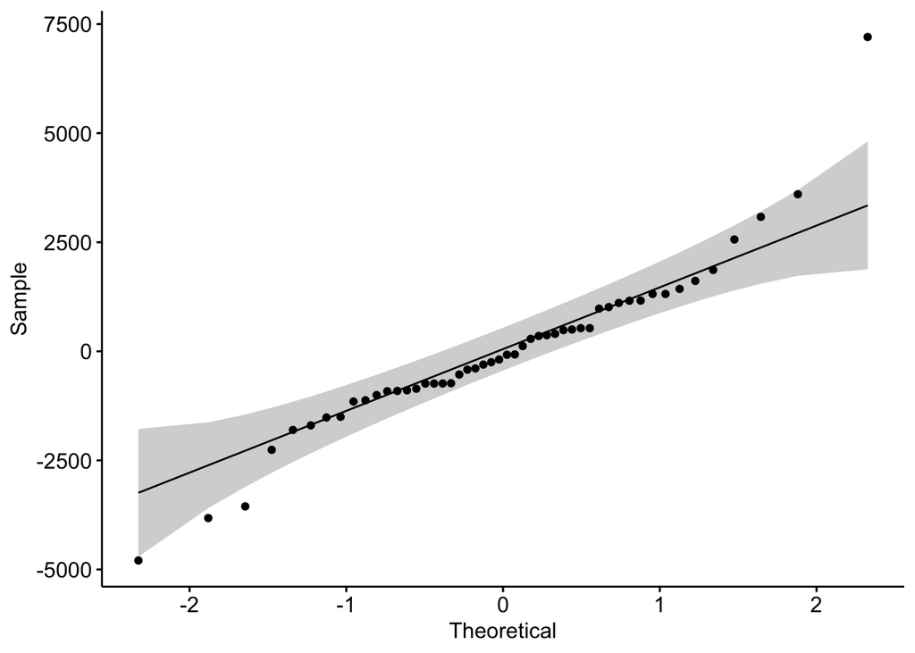

Looking at the QQ plot, we can see that we have a fairly normal distributed data (even though there are some outliers).

```
## # A tibble: 1 × 9
##   r_squared adj_r_squared      mse  rmse sigma statistic  p_value    df  nobs
##       <dbl>         <dbl>    <dbl> <dbl> <dbl>     <dbl>    <dbl> <dbl> <dbl>
## 1     0.885         0.872 3514712. 1875. 1998.      67.9 1.45e-19     5    50
```

The summary table shows that we have a low p-value (compared to typical alpha, 0.05), proving that there is sufficient evidence to suggest that the overall model using mileage, year_produced, number_of_photos, feature_count, engine_capacity can be used to predict price of car.

But from computing regression table:

| term | estimate | std_error | statistic | p_value | lower_ci | upper_ci |
| --- | --- | --- | --- | --- | --- | --- |
| intercept | -7.107356e+05 | 1.031573e+05 | -6.889823 | 0.0000000 | -9.186356e+05 | -5.028357e+05 |
| mileage | -1.028070e-02 | 3.462000e-03 | -2.969589 | 0.0048138 | -1.725790e-02 | -3.303500e-03 |
| year_produced | 3.542177e+02 | 5.137933e+01 | 6.894168 | 0.0000000 | 2.506695e+02 | 4.577660e+02 |
| number_of_photos | 7.795782e+01 | 5.044359e+01 | 1.545446 | 0.1294014 | -2.370455e+01 | 1.796202e+02 |
| feature_count | 2.731120e+02 | 1.677935e+02 | 1.627668 | 0.1107363 | -6.505354e+01 | 6.112776e+02 |
| engine_capacity | 4.119229e+03 | 4.742896e+02 | 8.685049 | 0.0000000 | 3.163361e+03 | 5.075097e+03 |

## 6 Summary

### 6.1 Equation for Multiple Regression

The coefficients for each variable changes every time we run and sample data. We filter out the variables whose p-values are > 0.05. This equation dynamically updates and only includes the variables that are significantly contributing to price:

$$\hat{price\_usd} = -0.01 \times mileage + 354.22 \times year_produced +
4119.23 \times engine_capacity - 710735.65$$

## 7 References

[used-car-catalog](https://www.kaggle.com/datasets/lepchenkov/usedcarscatalog?resource=download)  
[multiple regression notes](https://clemson.instructure.com/courses/249281/pages/notes-multiple-regression?module_item_id=4647358)  
[image of purchasing a Used Car](https://s3.us-east-2.amazonaws.com/irwin-ag/buying-used/Figuring-Out-Need-Used-Cars-2.jpg)

## 8 Personal Information

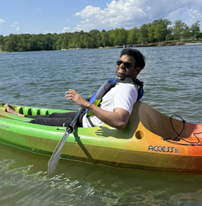

Utkal Sirikonda

Hello, I’m a Computer Science Graduate student passionate about learning new things. I work as a Software Engineer at Tabbi. I’m into adventure in my free time.

## 9 Code

### 9.1 Data Processing

```r
# Load required libraries
library(tidyverse)
library(DT)
library(car)
library(tibble)
library(ggpubr)
library(rstatix)
library(moderndive)
library(glue)

# Importing data
input_data <- read.csv("cars.csv", header = TRUE, stringsAsFactors = FALSE)

# Drop NAs
processed_data <- input_data %>%
  drop_na(manufacturer_name, model_name, year_produced)

#Convert Boolean Columns to Logical Type (TRUE/FALSE).

processed_data <- processed_data %>%
  mutate(across(c(engine_has_gas, has_warranty, is_exchangeable,starts_with("feature_")),
                ~ . == "True"))

# Reshape feature_0 to feature_9 into a feature_count.

processed_data <- processed_data %>%
  mutate(feature_count = rowSums(select(., starts_with("feature_"))))


# Filter out un-required variables.

processed_data <- processed_data %>%
  select(manufacturer_name, model_name, year_produced,
         engine_type, engine_capacity, transmission,
         body_type, drivetrain, color, mileage = odometer_value, engine_fuel,state,location_region,number_of_photos,
         price_usd, has_warranty, is_exchangeable,duration_listed,up_counter, feature_count)


# Final Data - Sampling

# QQ Plot over processed data

model <- lm(price_usd ~ manufacturer_name, data = processed_data)

ggqqplot(residuals(model))

# Mileage vs Price

processed_data %>% ggplot(aes(x=mileage, y=price_usd)) + geom_point()

# Taking 50 random samples from processed data:

sampled_data <- processed_data %>% slice_sample(n = 50)


# Descriptive Statistics

desc_stats <- processed_data %>%
  select(where(is.numeric)) %>%
  pivot_longer(cols = everything(), names_to = "variable_name", values_to = "value") %>%
  group_by(variable_name) %>%
  summarise(
    count = sum(!is.na(value)),
    mean = mean(value, na.rm = TRUE),
    sd = sd(value, na.rm = TRUE),
    .groups = "drop"
  )

datatable(desc_stats)


# Multiple Regression to estimate Price

# Plots
sampled_data %>% ggplot(aes(x=mileage, y=price_usd)) + geom_point()
sampled_data %>% ggplot(aes(x=year_produced, y=price_usd)) + geom_point()
#.
#.
#.

# model
multi_model <- lm(price_usd ~ mileage + year_produced + number_of_photos + feature_count + engine_capacity, data = sampled_data)

# QQ Plot of residuals
ggqqplot(residuals(multi_model))

# Regression summary
summary <- get_regression_summaries(multi_model, digits = 25)


# Equation

# {r, results='asis'} # keep asis to avoid the equation shown as a comment

# Filter out significant terms (p < 0.05)

significant_terms <- regression_table %>%
  filter(p_value < 0.05)

# Extract intercept separately

intercept_row <- significant_terms %>% filter(term == "intercept")
intercept_value <- if (nrow(intercept_row) > 0) round(intercept_row$estimate, 2) else 0

# Build terms string (excluding intercept)

term_components <- significant_terms %>%
  filter(term != "intercept") %>%
  mutate(
    component = glue("{round(estimate, 2)} \\times {term}")
  ) %>%
  pull(component)

# Combine components and intercept

equation_body <- paste(term_components, collapse = " + ")

# Add intercept with sign

if (intercept_value != 0) {
  intercept_text <- if (intercept_value < 0) {
    glue("- {abs(intercept_value)}")
  } else {
    glue("+ {intercept_value}")
  }
  equation_body <- glue("{equation_body} {intercept_text}")
}

# Final equation

reg_eq <- glue("$$\n\\hat{{price\\_usd}} = {equation_body}\n$$")

# Show the Latex equation
cat(reg_eq)
```